# Worldwide Governance Indicators 1996–2019

**6 Dimensions of Governance.**

1. Control of Corruption
2. Voice and Accountability
3. Rule of Law
4. Regulatory Quality
5. Political Stability and Absence of Violence/Terrorism
6. Government Effectiveness

**5 Synergy Groups**

1. Andean
2. APAC
3. Baltic
4. MidEast
5. Nordic

*A synergy group is a set of countries whose peoples have a high degree of shared culture, communication and commerce.*

**2 Questions**

*Anova : Do governments progress within synergy groups ?*

*Linear Regression : To what extent does Voice and Accountability drive Control of Corruption ?*

## Example Data : Voice And Accountability

captures *perceptions* of the extent to which a country’s citizens are able to participate in selecting their government, as well as freedom of expression, freedom of association, and a free media.

| Country | *1996* | *2004* | *2012* | *2019* | Progress |
| --- | --- | --- | --- | --- | --- |
| Korea North | -1.924 | -2.068 | -2.240 | -2.195 | -0.271 |
| Cuba | -1.425 | -1.786 | -1.515 | -1.424 | 0.001 |
| United States | 1.349 | 1.328 | 1.162 | 0.965 | -0.383 |
| Norway | 1.563 | 1.704 | 1.728 | 1.687 | 0.124 |

## Example Data : Control of Corruption

captures *perceptions* of the extent to which public power is exercised for private gain

| Country | *1996* | *2004* | *2012* | *2019* | Progress |
| --- | --- | --- | --- | --- | --- |
| Uganda | -0.724 | -0.779 | -0.988 | -1.166 | -0.442 |
| Nicaragua | -0.565 | -0.395 | -0.775 | -1.122 | -0.557 |
| United States | 1.571 | 1.833 | 1.411 | 1.215 | -0.356 |
| New Zealand | 2.110 | 2.377 | 2.316 | 2.170 | 0.060 |

## Andean Countries

### Voice and Accountability Control of Corruption

| Country | *1996* | *2019* | Progress |
| --- | --- | --- | --- |
| Argentina | 0.392 | 0.600 | 0.209 |
| Bolivia | 0.156 | -0.091 | -0.247 |
| Brazil | 0.242 | 0.344 | 0.102 |
| Chile | 0.723 | 1.020 | 0.297 |
| Colombia | -0.511 | 0.229 | 0.740 |
| Ecuador | 0.013 | 0.061 | 0.048 |
| Peru | -0.530 | 0.286 | 0.816 |
| Paraguay | -0.122 | 0.082 | 0.205 |
| Uruguay | 0.830 | 1.257 | 0.427 |

| *1996* | *2019* | Progress |
| --- | --- | --- |
| -0.101 | -0.071 | 0.030 |
| -0.825 | -0.742 | 0.083 |
| -0.019 | -0.334 | -0.315 |
| 1.454 | 1.088 | -0.366 |
| -0.512 | -0.229 | 0.283 |
| -0.685 | -0.496 | 0.188 |
| -0.399 | -0.448 | -0.049 |
| -1.166 | -0.829 | 0.337 |
| 1.125 | 1.247 | 0.122 |

## APAC Countries

### Voice and Accountability Control of Corruption

| Country | *1996* | *2019* | Progress |
| --- | --- | --- | --- |
| China | -1.362 | -1.612 | -0.251 |
| Hong Kong | 0.334 | 0.209 | -0.124 |
| Singapore | 0.140 | -0.183 | -0.323 |
| Thailand | 0.311 | -0.827 | -1.138 |
| Taiwan | 0.673 | 0.996 | 0.323 |
| Viet Nam | -1.087 | -1.381 | -0.293 |

| *1996* | *2019* | Progress |
| --- | --- | --- |
| -0.271 | -0.323 | -0.052 |
| 1.445 | 1.672 | 0.228 |
| 2.107 | 2.159 | 0.052 |
| -0.361 | -0.407 | -0.046 |
| 0.581 | 1.045 | 0.464 |
| -0.490 | -0.514 | -0.024 |

## Baltic Countries

### Voice and Accountability Control of Corruption

| Country | *1996* | *2019* | Progress |
| --- | --- | --- | --- |
| Albania | -0.648 | 0.152 | 0.800 |
| Bosnia | -0.104 | -0.199 | -0.095 |
| Croatia | -0.161 | 0.535 | 0.696 |
| Macedonia | -0.387 | -0.002 | 0.386 |
| Serbia | -1.216 | 0.027 | 1.242 |
| Slovenia | 1.275 | 1.007 | -0.268 |

| *1996* | *2019* | Progress |
| --- | --- | --- |
| -0.894 | -0.529 | 0.365 |
| -0.271 | -0.613 | -0.343 |
| -0.579 | 0.126 | 0.704 |
| -0.614 | -0.409 | 0.204 |
| -1.140 | -0.446 | 0.695 |
| 1.114 | 0.906 | -0.208 |

## MidEast Countries

### Voice and Accountability Control of Corruption

| Country | *1996* | *2019* | Progress |
| --- | --- | --- | --- |
| Afghanistan | -1.909 | -0.988 | 0.921 |
| Iran | -0.951 | -1.370 | -0.419 |
| Iraq | -1.957 | -0.945 | 1.011 |
| Saudi Arabia | -1.499 | -1.617 | -0.118 |

| *1996* | *2019* | Progress |
| --- | --- | --- |
| -1.292 | -1.401 | -0.109 |
| -0.481 | -1.048 | -0.567 |
| -1.602 | -1.337 | 0.266 |
| -0.163 | 0.275 | 0.438 |

## Nordic Countries

### Voice and Accountability Control of Corruption

| Country | *1996* | *2019* | Progress |
| --- | --- | --- | --- |
| Denmark | 1.539 | 1.579 | 0.040 |
| Finland | 1.518 | 1.589 | 0.071 |
| Iceland | 1.462 | 1.334 | -0.128 |
| Norway | 1.563 | 1.687 | 0.124 |
| Sweden | 1.518 | 1.592 | 0.074 |

| *1996* | *2019* | Progress |
| --- | --- | --- |
| 2.231 | 2.107 | -0.124 |
| 2.207 | 2.153 | -0.054 |
| 1.733 | 1.708 | -0.025 |
| 2.139 | 2.073 | -0.065 |
| 2.174 | 2.118 | -0.056 |

## Group Summary

### Voice and Accountability Control of Corruption

[output not shown]

| *1996* | *2019* | Progress | SD |
| --- | --- | --- | --- |
| -0.125 | -0.090 | 0.035 | 0.244 |
| 0.502 | 0.605 | 0.104 | 0.205 |
| -0.397 | -0.161 | 0.236 | 0.443 |
| -0.885 | -0.878 | 0.007 | 0.446 |
| 2.097 | 2.032 | -0.065 | 0.036 |
| -0.041 | -0.106 | -0.064 | 0.482 |

## Review Normalcy : Frequency Distributions

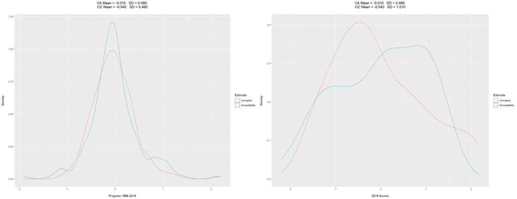

# Anova: Do governments progress as groups ?

## Control of Corruption 1996-2019 : Is Anova Appropriate ?

```
1)  Independence
2)  Normality within the groups
3)  Constant Variability
```

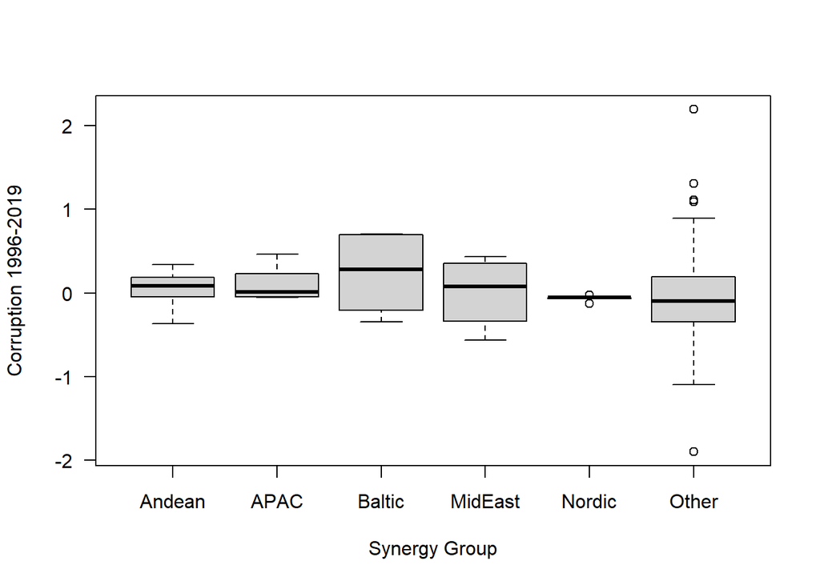

$H_0$ = All synergy groups have the same mean (Control of Corruption progress from 1996 to 2019 )

$H_A$ = Not all synergy groups have the same mean

$$SSE \ = \ \sum_i \sum_j (x_{ij} - \bar{x})^2$$

$$SSTr = \sum n_i(\bar{x}_i \ - \ \bar{x})^2$$

$$Group \ FStat \ = \ \frac{SSTr/(k-1)}{SSE/(n-k)} \ = \ \frac{MSG}{MSE}$$

## Model Summary and Anova : CC Progress

```
##
## Call:
## lm(formula = cc_progress ~ synergy_group, data = wgi_cc_va.df)
##
## Residuals:
##      Min       1Q   Median       3Q      Max
## -1.83098 -0.27048 -0.01498  0.25361  2.26502
##
## Coefficients:
##                      Estimate Std. Error t value Pr(>|t|)
## (Intercept)           0.03478    0.15384   0.226    0.821
## synergy_groupAPAC     0.06889    0.24324   0.283    0.777
## synergy_groupBaltic   0.20139    0.24324   0.828    0.409
## synergy_groupMidEast -0.02778    0.27734  -0.100    0.920
## synergy_groupNordic  -0.09958    0.25742  -0.387    0.699
## synergy_groupOther   -0.10380    0.15819  -0.656    0.513
##
## Residual standard error: 0.4615 on 181 degrees of freedom
## Multiple R-squared:  0.0195, Adjusted R-squared:  -0.007582
## F-statistic: 0.7201 on 5 and 181 DF,  p-value: 0.6092
```

```
## Analysis of Variance Table
##
## Response: cc_progress
##                Df Sum Sq Mean Sq F value Pr(>F)
## synergy_group   5  0.767 0.15337  0.7201 0.6092
## Residuals     181 38.553 0.21300
```

## Model Summary and Anova : CC Progress : Without Other

```
##
## Call:
## lm(formula = cc_progress ~ synergy_group, data = wgi_new.df)
##
## Residuals:
##     Min      1Q  Median      3Q     Max
## -0.5792 -0.1247  0.0043  0.1471  0.4678
##
## Coefficients:
##                      Estimate Std. Error t value Pr(>|t|)
## (Intercept)           0.03478    0.10040   0.346    0.732
## synergy_groupAPAC     0.06889    0.15875   0.434    0.668
## synergy_groupBaltic   0.20139    0.15875   1.269    0.216
## synergy_groupMidEast -0.02778    0.18100  -0.153    0.879
## synergy_groupNordic  -0.09958    0.16800  -0.593    0.559
##
## Residual standard error: 0.3012 on 25 degrees of freedom
## Multiple R-squared:  0.1135, Adjusted R-squared:  -0.02837
## F-statistic:   0.8 on 4 and 25 DF,  p-value: 0.5366
```

```
## Analysis of Variance Table
##
## Response: cc_progress
##               Df Sum Sq  Mean Sq F value Pr(>F)
## synergy_group  4 0.2903 0.072575     0.8 0.5366
## Residuals     25 2.2681 0.090723
```

## Model Summary and Anova : 2019 CC Scores : Without Other

```
##
## Call:
## lm(formula = cc_2019 ~ synergy_group, data = wgi_new.df)
##
## Residuals:
##     Min      1Q  Median      3Q     Max
## -1.1193 -0.4405 -0.2069  0.2454  1.5537
##
## Coefficients:
##                      Estimate Std. Error t value Pr(>|t|)
## (Intercept)          -0.09044    0.25892  -0.349    0.730
## synergy_groupAPAC     0.69578    0.40938   1.700    0.102
## synergy_groupBaltic  -0.07039    0.40938  -0.172    0.865
## synergy_groupMidEast -0.78731    0.46677  -1.687    0.104
## synergy_groupNordic   2.12224    0.43325   4.898 4.85e-05 ***
## ---
## Signif. codes:  0 '***' 0.001 '**' 0.01 '*' 0.05 '.' 0.1 ' ' 1
##
## Residual standard error: 0.7767 on 25 degrees of freedom
## Multiple R-squared:  0.6115, Adjusted R-squared:  0.5493
## F-statistic: 9.838 on 4 and 25 DF,  p-value: 6.369e-05
```

```
## Analysis of Variance Table
##
## Response: cc_2019
##               Df Sum Sq Mean Sq F value    Pr(>F)
## synergy_group  4 23.741  5.9353  9.8376 6.369e-05 ***
## Residuals     25 15.083  0.6033
## ---
## Signif. codes:  0 '***' 0.001 '**' 0.01 '*' 0.05 '.' 0.1 ' ' 1
```

# Linear Regression : Does Accountability Effect Corruption ?

$H_0$ = Accountability and Corruption **do not have** a positive correlation

$H_A$ = Accountability and Corruption **do have** a positive correlation

## Progress 1996-2019 : Is Least Squared Regression Appropriate ?

```
1)  Linearity
2)  Normality of the Residuals
3)  Constant Variability
4)  Independence
```

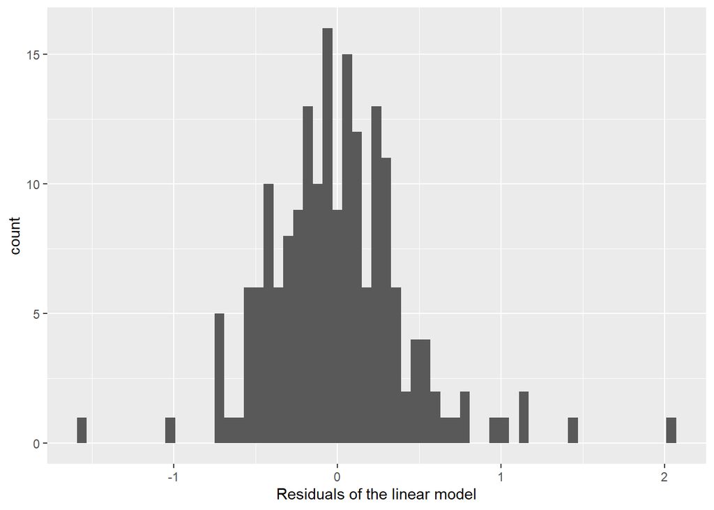

QQNorm :

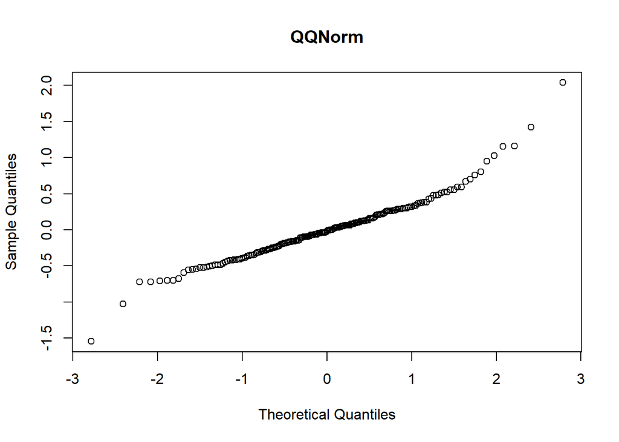

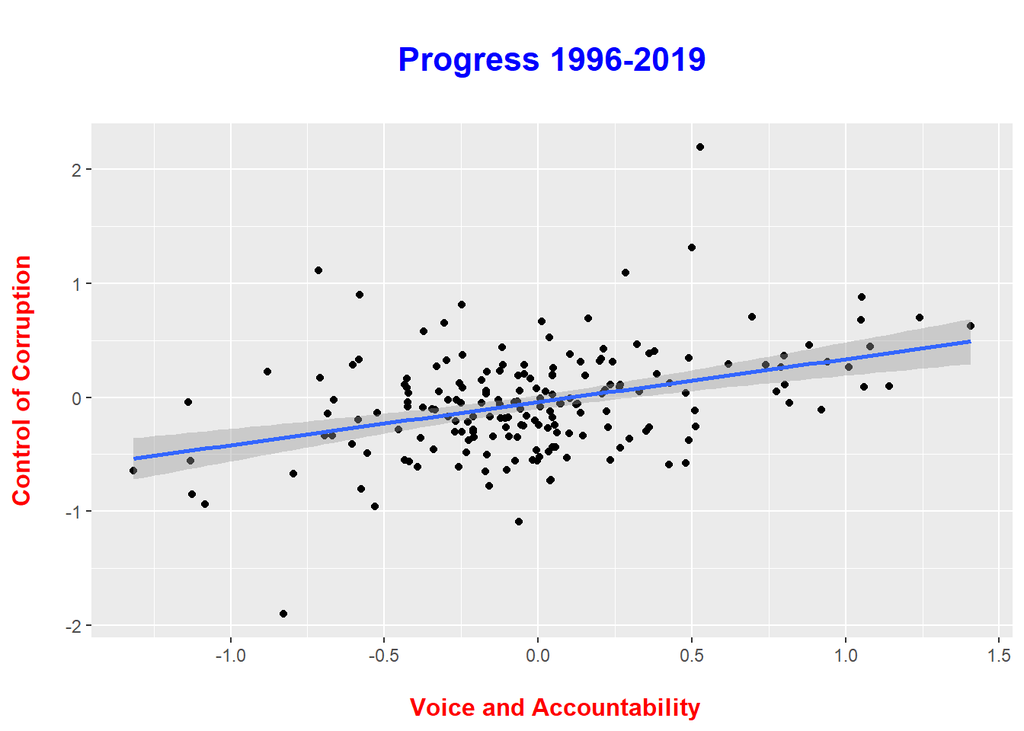

1. Correlation = **.38**

$$R \ = \ \frac{1}{n-1} \ \sum_{i=1} \ \frac{x_i-\bar{x}}{S_x} \ \frac{y_i-\bar{y}}{S_y}$$

2. Residual Standard Error = **0.42**

$$RSE ( \sigma^2) \ = \ \sqrt{\frac{\sum (y_i \ - \ \hat{y} )}{n-2}}$$

3. Variances = **.21** and **.22**
4. F Statistic = **32.20**

$$Linear F Stat \ = \ \frac{MSM}{MSE} = \ (\frac{m}{se})^2 \ = (\frac{.377}{.066})^2$$

$$CC_{progress} \ = \ .377 * VA_{progress} - 0.04$$

```
##
## Call:
## lm(formula = cc_progress ~ va_progress, data = wgi_cc_va.df)
##
## Residuals:
##      Min       1Q   Median       3Q      Max
## -1.54570 -0.26506 -0.01682  0.23090  2.03858
##
## Coefficients:
##             Estimate Std. Error t value Pr(>|t|)
## (Intercept) -0.04169    0.03113  -1.339    0.182
## va_progress  0.37709    0.06645   5.675 5.28e-08 ***
## ---
## Signif. codes:  0 '***' 0.001 '**' 0.01 '*' 0.05 '.' 0.1 ' ' 1
##
## Residual standard error: 0.4255 on 185 degrees of freedom
## Multiple R-squared:  0.1483, Adjusted R-squared:  0.1437
## F-statistic:  32.2 on 1 and 185 DF,  p-value: 5.284e-08
```

5. Two Sample T-Test

$$t \ = \ \frac{(\bar{X_1} \ - \ \bar{X_2})}{\sqrt{ \frac{s_1^2}{n_1} + \frac{s_2^2}{n_2}}}$$

[output not shown]

## Progress 1996-2019: Predictions

| va_progress | cc_progress |
| --- | --- |
| -2.0 | -0.7958791 |
| -1.6 | -0.6450415 |
| -1.2 | -0.4942038 |
| -0.8 | -0.3433661 |
| -0.4 | -0.1925284 |
| 0.0 | -0.0416907 |
| 0.4 | 0.1091470 |
| 0.8 | 0.2599847 |
| 1.2 | 0.4108224 |
| 1.6 | 0.5616601 |
| 2.0 | 0.7124977 |

# Conclusion